# STT 511 HW 2

Thomas Billman

January 29, 2018

# R code for solving problem 3.7

We begin by reading in the data and finding the means

```r
tensile.strength<-read.table(file = url("https://raw.githubusercontent.com/tbillman/Ghosh-511/master/Data/tensilestrength.txt"),header=T)
grp.means <- with(tensile.strength, tapply(TS,MT,mean))
```

First, we convert each variable to factor

```r
tensile.strength$MT <- as.factor(tensile.strength$MT)
tensile.strength$run <- as.factor(tensile.strength$run)
```

Next, we run the model and find the analysis of variance

```r
tensile.strength.aov <-aov(TS~MT,tensile.strength)
```

Testing the hypothesis (based on overall F-test)

```r
summary(tensile.strength.aov)
```

```
##             Df Sum Sq Mean Sq F value   Pr(>F)
## MT           3 489740  163247   12.73 0.000489 ***
## Residuals   12 153908   12826
## ---
## Signif. codes:  0 '***' 0.001 '**' 0.01 '*' 0.05 '.' 0.1 ' ' 1
```

Extracting the residuals

```r
aov_residuals <- resid(object=tensile.strength.aov)
```

Estimating the treatment means

```r
model.tables(tensile.strength.aov)
```

```
## Tables of effects
##
##  MT
## MT
##       1       2       3       4
##   39.19  224.44    1.94 -265.56
```

Package for Fisher LSD comparison

```r
#install.packages("agricolae") install this if you don't have it
library("agricolae")
```

Test

```r
output<-LSD.test(tensile.strength.aov, "MT")
output
```

```
## $statistics
##    MSerror Df     Mean       CV  t.value      LSD
##   12825.69 12 2931.812 3.862817 2.178813 174.4798
##
## $parameters
##         test p.ajusted name.t ntr alpha
##   Fisher-LSD      none     MT   4  0.05
##
## $means
##        TS       std r      LCL      UCL  Min  Max     Q25    Q50     Q75
## 1 2971.00 120.55704 4 2847.624 3094.376 2865 3129 2883.75 2945.0 3032.25
## 2 3156.25 135.97641 4 3032.874 3279.626 2975 3300 3106.25 3175.0 3225.00
## 3 2933.75 108.27242 4 2810.374 3057.126 2800 3050 2875.00 2942.5 3001.25
## 4 2666.25  80.97067 4 2542.874 2789.626 2600 2765 2600.00 2650.0 2716.25
##
## $comparison
## NULL
##
## $groups
##        TS groups
## 2 3156.25      a
## 1 2971.00      b
## 3 2933.75      b
## 4 2666.25      c
##
## attr(,"class")
## [1] "group"
```

Tukey’s multiple pairwise comparison

```r
output<-HSD.test(tensile.strength.aov, "MT")
output
```

```
## $statistics
##    MSerror Df     Mean       CV      MSD
##   12825.69 12 2931.812 3.862817 237.7503
##
## $parameters
##    test name.t ntr StudentizedRange alpha
##   Tukey     MT   4          4.19866  0.05
##
## $means
##        TS       std r  Min  Max     Q25    Q50     Q75
## 1 2971.00 120.55704 4 2865 3129 2883.75 2945.0 3032.25
## 2 3156.25 135.97641 4 2975 3300 3106.25 3175.0 3225.00
## 3 2933.75 108.27242 4 2800 3050 2875.00 2942.5 3001.25
## 4 2666.25  80.97067 4 2600 2765 2600.00 2650.0 2716.25
##
## $comparison
## NULL
##
## $groups
##        TS groups
## 2 3156.25      a
## 1 2971.00      a
## 3 2933.75      a
## 4 2666.25      b
##
## attr(,"class")
## [1] "group"
```

```r
##(d), (e), and (f)
opar <- par(mfrow=c(2,2),cex=.8)
plot(tensile.strength.aov)
```

[output not shown]

```r
par(opar)
```

Constructing normal probability plot with theoretical line

```r
qqnorm(aov_residuals)

qqline(aov_residuals)
```

[output not shown]

Specific residual vs predictor plot

```r
aov_predictor<-fitted(tensile.strength.aov)

plot(aov_predictor,aov_residuals)
```

[output not shown]

Producing a scatterplot

```r
plot(tensile.strength.aov)
```

[output not shown]

## Work for problem 3.10

Read in the data

```r
cot = cbind(c(rep("A",5), rep("B", 5),
              rep("C",5), rep("D", 5), rep("E",5)),
            c(7,7,15,11,9,
              12,17,12,18,18,
              14,19,19,18,18,
              19,25,22,19,23,
              7,11,10,15,11)
)
colnames(cot) = c("group","reading")
cot = as.data.frame(cot)
```

Factoring

```r
cot$group <- as.factor(cot$group)
cot$reading <- as.numeric(cot$reading)
```

Next, we run the model and find the analysis of variance

```r
cot.aov <-aov(reading~group,cot)
```

Testing the hypothesis (based on overall F-test)

```r
summary(cot.aov)
```

```
##             Df Sum Sq Mean Sq F value Pr(>F)
## group        4  90.24   22.56   2.104  0.118
## Residuals   20 214.40   10.72
```

Extracting the residuals

```r
aov_cot_residuals <- resid(object=cot.aov)
```

Estimating the treatment means

```r
model.tables(cot.aov)
```

```
## Tables of effects
##
##  group
## group
##     A     B     C     D     E
##  1.92 -1.68 -0.08  2.32 -2.48
```

LSD Comparison Test

```r
output<-LSD.test(cot.aov, "group")
output
```

```
## $statistics
##   MSerror Df Mean       CV  t.value      LSD
##     10.72 20 6.88 47.58926 2.085963 4.319506
##
## $parameters
##         test p.ajusted name.t ntr alpha
##   Fisher-LSD      none  group   5  0.05
##
## $means
##   reading      std r      LCL       UCL Min Max Q25 Q50 Q75
## A     8.8 4.969909 5 5.745648 11.854352   2  13   5  12  12
## B     5.2 2.049390 5 2.145648  8.254352   3   7   3   6   7
## C     6.8 1.643168 5 3.745648  9.854352   4   8   7   7   8
## D     9.2 1.303840 5 6.145648 12.254352   8  11   8   9  10
## E     4.4 4.505552 5 1.345648  7.454352   1  12   2   2   5
##
## $comparison
## NULL
##
## $groups
##   reading groups
## D     9.2      a
## A     8.8      a
## C     6.8     ab
## B     5.2     ab
## E     4.4      b
##
## attr(,"class")
## [1] "group"
```

Tukey’s multiple pairwise comparison

```r
output<-HSD.test(tensile.strength.aov, "MT")
output
```

```
## $statistics
##    MSerror Df     Mean       CV      MSD
##   12825.69 12 2931.812 3.862817 237.7503
##
## $parameters
##    test name.t ntr StudentizedRange alpha
##   Tukey     MT   4          4.19866  0.05
##
## $means
##        TS       std r  Min  Max     Q25    Q50     Q75
## 1 2971.00 120.55704 4 2865 3129 2883.75 2945.0 3032.25
## 2 3156.25 135.97641 4 2975 3300 3106.25 3175.0 3225.00
## 3 2933.75 108.27242 4 2800 3050 2875.00 2942.5 3001.25
## 4 2666.25  80.97067 4 2600 2765 2600.00 2650.0 2716.25
##
## $comparison
## NULL
##
## $groups
##        TS groups
## 2 3156.25      a
## 1 2971.00      a
## 3 2933.75      a
## 4 2666.25      b
##
## attr(,"class")
## [1] "group"
```

```r
##(d), (e), and (f)
opar <- par(mfrow=c(2,2),cex=.8)
plot(tensile.strength.aov)
```

[output not shown]

```r
par(opar)
```

Constructing normal probability plot with theoretical line

```r
qqnorm(aov_residuals)

qqline(aov_residuals)
```

[output not shown]

Specific residual vs predictor plot

```r
aov_predictor<-fitted(tensile.strength.aov)

plot(aov_predictor,aov_residuals)
```

[output not shown]

Producing a scatterplot

```r
plot(tensile.strength.aov)
```

[output not shown]

## Work for problem 3.12

Read in the data

```r
dose = cbind(c(rep("A",4), rep("B", 4),
              rep("C",4)),
            c(24, 28, 37, 30,
              37, 44, 31, 35,
              42, 47, 52, 38)
)
colnames(dose) = c("dosage","activty")
dose = as.data.frame(dose)
```

Factoring

```r
dose$dosage <- as.factor(dose$dosage)
dose$activity <- as.numeric(levels(dose$activty)[as.numeric(dose$activty)])
```

Next, we run the model and find the analysis of variance

```r
dose.aov <-aov(activity~dosage,dose)
```

Testing the hypothesis (based on overall F-test)

```r
summary(dose.aov)
```

```
##             Df Sum Sq Mean Sq F value Pr(>F)
## dosage       2  450.7  225.33   7.036 0.0145 *
## Residuals    9  288.2   32.03
## ---
## Signif. codes:  0 '***' 0.001 '**' 0.01 '*' 0.05 '.' 0.1 ' ' 1
```

Extracting the residuals

```r
aov_dose_residuals <- resid(object=dose.aov)
```

Estimating the treatment means

```r
model.tables(dose.aov)
```

```
## Tables of effects
##
##  dosage
## dosage
##      A      B      C
## -7.333 -0.333  7.667
```

LSD Comparison Test

```r
output<-LSD.test(dose.aov, "dosage")
output
```

```
## $statistics
##    MSerror Df     Mean       CV  t.value      LSD
##   32.02778  9 37.08333 15.26106 2.262157 9.052555
##
## $parameters
##         test p.ajusted name.t ntr alpha
##   Fisher-LSD      none dosage   3  0.05
##
## $means
##   activity      std r      LCL      UCL Min Max Q25  Q50   Q75
## A    29.75 5.439056 4 23.34888 36.15112  24  37  27 29.0 31.75
## B    36.75 5.439056 4 30.34888 43.15112  31  44  34 36.0 38.75
## C    44.75 6.075909 4 38.34888 51.15112  38  52  41 44.5 48.25
##
## $comparison
## NULL
##
## $groups
##   activity groups
## C    44.75      a
## B    36.75     ab
## A    29.75      b
##
## attr(,"class")
## [1] "group"
```

Tukey’s multiple pairwise comparison

```r
output<-HSD.test(tensile.strength.aov, "MT")
output
```

```
## $statistics
##    MSerror Df     Mean       CV      MSD
##   12825.69 12 2931.812 3.862817 237.7503
##
## $parameters
##    test name.t ntr StudentizedRange alpha
##   Tukey     MT   4          4.19866  0.05
##
## $means
##        TS       std r  Min  Max     Q25    Q50     Q75
## 1 2971.00 120.55704 4 2865 3129 2883.75 2945.0 3032.25
## 2 3156.25 135.97641 4 2975 3300 3106.25 3175.0 3225.00
## 3 2933.75 108.27242 4 2800 3050 2875.00 2942.5 3001.25
## 4 2666.25  80.97067 4 2600 2765 2600.00 2650.0 2716.25
##
## $comparison
## NULL
##
## $groups
##        TS groups
## 2 3156.25      a
## 1 2971.00      a
## 3 2933.75      a
## 4 2666.25      b
##
## attr(,"class")
## [1] "group"
```

```r
##(d), (e), and (f)
opar <- par(mfrow=c(2,2),cex=.8)
plot(tensile.strength.aov)
```

[output not shown]

```r
par(opar)
```

Constructing normal probability plot with theoretical line

```r
qqnorm(aov_residuals)

qqline(aov_residuals)
```

[output not shown]

Specific residual vs predictor plot

```r
aov_predictor<-fitted(tensile.strength.aov)

plot(aov_predictor,aov_residuals)
```

[output not shown]

Producing a scatterplot

```r
plot(tensile.strength.aov)
```

[output not shown]

## Work for problem 3.27

Read in the data

```r
catl = cbind(c(rep("A",5), rep("B", 4),
              rep("C",3), rep("D",4)),
            c(58.2, 57.2, 58.4, 55.8, 54.9,
              56.3, 54.5, 57.0, 55.3,
              50.1, 54.2, 55.4,
              52.9, 49.9, 50.0, 51.7)
)
colnames(catl) = c("catalyst","concentration")
catl = as.data.frame(catl)
```

Factoring

```r
catl$catalyst <- as.factor(catl$catalyst)
catl$concentration <- as.numeric(levels(catl$concentration)[as.numeric(catl$concentration)])
```

Next, we run the model and find the analysis of variance

```r
catl.aov <-aov(concentration~catalyst,catl)
```

Testing the hypothesis (based on overall F-test)

```r
summary(catl.aov)
```

```
##             Df Sum Sq Mean Sq F value  Pr(>F)
## catalyst     3  85.68   28.56   9.916 0.00144 **
## Residuals   12  34.56    2.88
## ---
## Signif. codes:  0 '***' 0.001 '**' 0.01 '*' 0.05 '.' 0.1 ' ' 1
```

Extracting the residuals

```r
aov_catl_residuals <- resid(object=catl.aov)
```

Constructing normal probability plot with theoretical line

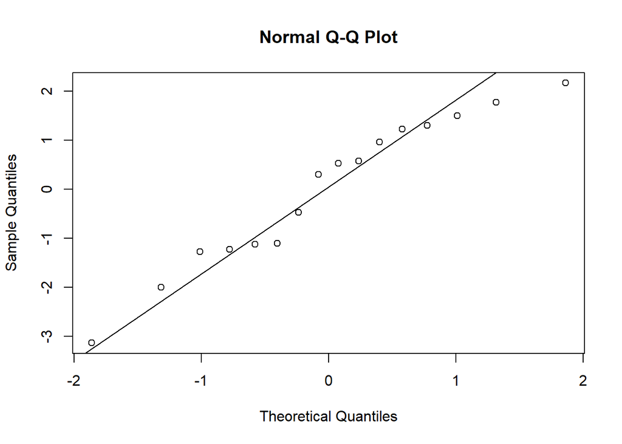

```r
qqnorm(aov_catl_residuals)

qqline(aov_catl_residuals)
```

Specific residual vs predictor plot

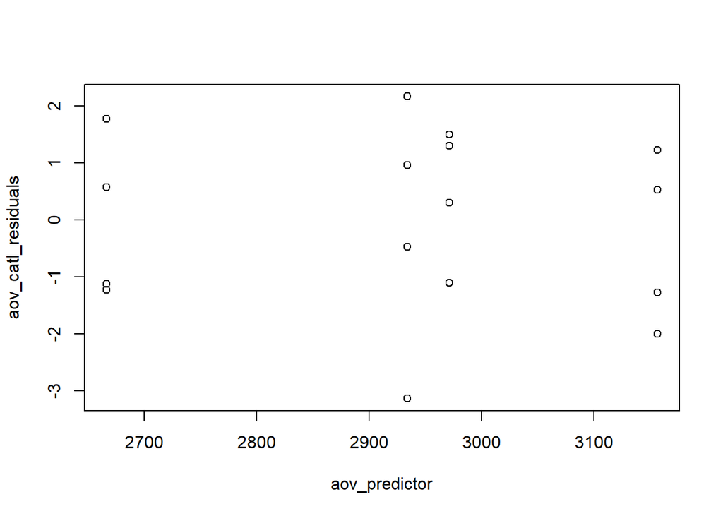

```r
aov_predictor<-fitted(tensile.strength.aov)

plot(aov_predictor,aov_catl_residuals)
```